# Summary of analysis results

nf-core/ampliseq workflow version 2.14.0

June 25, 2025

# 1 Abstract

The bioinformatics analysis pipeline [nfcore/ampliseq](https://nf-co.re/ampliseq) is used for amplicon sequencing, supporting denoising of any amplicon and supports a variety of taxonomic databases for taxonomic assignment including 16S, ITS, CO1 and 18S.

# 2 Data input

Pipeline input was saved in folder input.

Sequencing data was provided in the samplesheet file `16s_samplesheet.tsv` that is displayed below:

|  | sampleID | forwardReads | reverseReads |
| --- | --- | --- | --- |
| 1 | K10MK | /cfs/klemming/projects/supr/psoriasis_suscep_microb/Support_7993/data/raw_data/K10MK_S1_L001_R1_001.fastq.gz | /cfs/klemming/projects/supr/psoriasis_suscep_microb/Support_7993/data/raw_data/K10MK_S1_L001_R2_001.fastq.gz |
| 2 | K11MK | /cfs/klemming/projects/supr/psoriasis_suscep_microb/Support_7993/data/raw_data/K11MK_S3_L001_R1_001.fastq.gz | /cfs/klemming/projects/supr/psoriasis_suscep_microb/Support_7993/data/raw_data/K11MK_S3_L001_R2_001.fastq.gz |
| 3 | K12MK | /cfs/klemming/projects/supr/psoriasis_suscep_microb/Support_7993/data/raw_data/K12MK_S5_L001_R1_001.fastq.gz | /cfs/klemming/projects/supr/psoriasis_suscep_microb/Support_7993/data/raw_data/K12MK_S5_L001_R2_001.fastq.gz |
| 4 | K13MK | /cfs/klemming/projects/supr/psoriasis_suscep_microb/Support_7993/data/raw_data/K13MK_S7_L001_R1_001.fastq.gz | /cfs/klemming/projects/supr/psoriasis_suscep_microb/Support_7993/data/raw_data/K13MK_S7_L001_R2_001.fastq.gz |
| 5 | K14MK | /cfs/klemming/projects/supr/psoriasis_suscep_microb/Support_7993/data/raw_data/K14MK_S1_L001_R1_001.fastq.gz | /cfs/klemming/projects/supr/psoriasis_suscep_microb/Support_7993/data/raw_data/K14MK_S1_L001_R2_001.fastq.gz |
| 6 | K15MK | /cfs/klemming/projects/supr/psoriasis_suscep_microb/Support_7993/data/raw_data/K15MK_S3_L001_R1_001.fastq.gz | /cfs/klemming/projects/supr/psoriasis_suscep_microb/Support_7993/data/raw_data/K15MK_S3_L001_R2_001.fastq.gz |
| 7 | K16MK | /cfs/klemming/projects/supr/psoriasis_suscep_microb/Support_7993/data/raw_data/K16MK_S5_L001_R1_001.fastq.gz | /cfs/klemming/projects/supr/psoriasis_suscep_microb/Support_7993/data/raw_data/K16MK_S5_L001_R2_001.fastq.gz |
| 8 | K17MK | /cfs/klemming/projects/supr/psoriasis_suscep_microb/Support_7993/data/raw_data/K17MK_S7_L001_R1_001.fastq.gz | /cfs/klemming/projects/supr/psoriasis_suscep_microb/Support_7993/data/raw_data/K17MK_S7_L001_R2_001.fastq.gz |
| 9 | K18MK | /cfs/klemming/projects/supr/psoriasis_suscep_microb/Support_7993/data/raw_data/K18MK_S9_L001_R1_001.fastq.gz | /cfs/klemming/projects/supr/psoriasis_suscep_microb/Support_7993/data/raw_data/K18MK_S9_L001_R2_001.fastq.gz |
| 10 | K19MK | /cfs/klemming/projects/supr/psoriasis_suscep_microb/Support_7993/data/raw_data/K19MK_S11_L001_R1_001.fastq.gz | /cfs/klemming/projects/supr/psoriasis_suscep_microb/Support_7993/data/raw_data/K19MK_S11_L001_R2_001.fastq.gz |

[output cut: 136 more lines]

# 3 Preprocessing

## 3.1 FastQC

[FastQC](https://www.bioinformatics.babraham.ac.uk/projects/fastqc/) gives general quality metrics about your sequenced reads. It provides information about the quality score distribution across your reads, per base sequence content (%A/T/G/C), adapter contamination and overrepresented sequences. The sequence quality was checked using FastQC and resulting data was aggregated using the FastQC module of [MultiQC](https://multiqc.info/). For more quality controls and per sample quality checks you can check the full MultiQC report, which can be found in multiqc/multiqc_report.html.

[figure not shown]

## 3.2 Primer removal with Cutadapt

[Cutadapt](https://journal.embnet.org/index.php/embnetjournal/article/view/200) is trimming primer sequences from sequencing reads. Primer sequences are non-biological sequences that often introduce point mutations that do not reflect sample sequences. This is especially true for degenerated PCR primer. If primer trimming were to be omitted, artifactual amplicon sequence variants might be computed by the denoising tool or sequences might be lost due to being labelled as PCR chimera. Primers were trimmed using cutadapt and all untrimmed sequences were discarded. Sequences that did not contain primer sequences were considered artifacts. Less than 31.5% of the sequences were discarded per sample and a mean of 94.8% of the sequences per sample passed the filtering. Cutadapt results can be found in folder cutadapt.

|  | sample | total_processed | reverse_complemented | passing_filters | passing_filters_percent | doubleprimer_reverse_complemented | doubleprimer_passing_filters | doubleprimer_passing_filters_percent |
| --- | --- | --- | --- | --- | --- | --- | --- | --- |
| 1 | K10MK | 726,900 |  | 700,067 | 96.3% |  | 699,771 | 100.0% |
| 2 | K11MK | 691,042 |  | 661,182 | 95.7% |  | 660,844 | 99.9% |
| 3 | K12MK | 764,544 |  | 733,017 | 95.9% |  | 732,722 | 100.0% |
| 4 | K13MK | 754,296 |  | 734,520 | 97.4% |  | 734,216 | 100.0% |
| 5 | K14MK | 676,298 |  | 633,772 | 93.7% |  | 633,447 | 99.9% |
| 6 | K15MK | 578,793 |  | 482,166 | 83.3% |  | 481,720 | 99.9% |
| 7 | K16MK | 520,904 |  | 480,456 | 92.2% |  | 480,135 | 99.9% |
| 8 | K17MK | 455,038 |  | 428,830 | 94.2% |  | 428,643 | 100.0% |
| 9 | K18MK | 475,843 |  | 453,258 | 95.3% |  | 452,991 | 99.9% |
| 10 | K19MK | 488,597 |  | 463,583 | 94.9% |  | 463,256 | 99.9% |

[output cut: 136 more lines]

## 3.3 Quality filtering using DADA2

Additional quality filtering can improve sequence recovery. Often it is advised trimming the last few nucleotides to avoid less well-controlled errors that can arise there. Reads were trimmed to a specific length and the length cutoff was automatically determined by the median quality of all input reads. Reads were trimmed before median quality drops below 25 and at least 75% of reads are retained, resulting in a trim of forward reads at 252 bp and reverse reads at 201 bp, reads shorter than this were discarded. Reads with more than 2 expected errors were discarded. Read counts passing the filter are shown in section ‘Read counts per sample’ column ‘filtered’.

**Quality profiles:**

Forward (left) and reverse (right) read quality stats for incoming data:

[figure not shown]

Forward (left) and reverse (right) read quality stats for preprocessed data:

[figure not shown]

Overall read quality profiles are displayed as heat map of the frequency of each quality score at each base position. The mean quality score at each position is shown by the green line, and the quartiles of the quality score distribution by the orange lines. The red line shows the scaled proportion of reads that extend to at least that position. Original plots can be found in folder dada2/QC/ with names that end in `_qual_stats.pdf`.

# 4 ASV inference using DADA2

[DADA2](https://doi.org/10.1038/nmeth.3869) performs fast and accurate sample inference from amplicon data with single-nucleotide resolution. It infers exact amplicon sequence variants (ASVs) from amplicon data with fewer false positives than many other methods while maintaining high sensitivity.

DADA2 reduces sequence errors and dereplicates sequences by quality filtering, denoising, read pair merging (for paired end Illumina reads only) and PCR chimera removal.

## 4.1 Error correction

Read error correction was performed using estimated error rates, visualized below. Error rates for forward reads are at the left side and reverse reads are at the right side.

[figure not shown]

Estimated error rates are displayed for each possible transition. The black line shows the estimated error rates after convergence of the machine-learning algorithm. The red line shows the error rates expected under the nominal definition of the Q-score. The estimated error rates (black line) should be a good fit to the observed rates (points), and the error rates should drop with increased quality. Original plots can be found in folder dada2/QC/ with names that end in `.err.pdf`.

## 4.2 Read counts per sample

Tracking read numbers through DADA2 processing steps for each sample. The following table shows the read numbers after each processing stage. Processing stages are: input - read pairs into DADA2, filtered - read pairs passed quality filtering, denoisedF - forward reads after denoising, denoisedR - reverse reads after denoising, merged - successfully merged read pairs, nonchim - read pairs in non-chimeric sequences (final ASVs).

|  | sample | DADA2_input | filtered | denoisedF | denoisedR | merged | nonchim |
| --- | --- | --- | --- | --- | --- | --- | --- |
| 1 | K10MK | 699771 | 341129 | 335865 | 338781 | 315012 | 288147 |
| 2 | K11MK | 660844 | 311336 | 307087 | 309417 | 290749 | 275035 |
| 3 | K12MK | 732722 | 350110 | 343988 | 347080 | 319734 | 294938 |
| 4 | K13MK | 734216 | 385384 | 373974 | 381265 | 340858 | 279605 |
| 5 | K14MK | 633447 | 352943 | 350415 | 351420 | 336385 | 317554 |
| 6 | K15MK | 481720 | 193380 | 192719 | 193123 | 190028 | 187985 |
| 7 | K16MK | 480135 | 280370 | 277476 | 278443 | 267002 | 259287 |
| 8 | K17MK | 428643 | 257299 | 255831 | 256502 | 247278 | 227732 |
| 9 | K18MK | 452991 | 286241 | 283497 | 284777 | 271693 | 250354 |
| 10 | K19MK | 463256 | 271458 | 269403 | 270321 | 259418 | 240394 |

[output cut: 136 more lines]

Samples with unusual low reads numbers relative to the number of expected ASVs should be treated cautiously, because the abundance estimate will be very granular and might vary strongly between (theoretical) replicates due to high impact of stochasticity.

Following, the numbers of the table above are shown in stacked barcharts as percentage of DADA2 input reads. Stacked barchart of read pair numbers (denoisedF & denoisedR halfed, because each pair is split) per sample and processing stage (display 10 samples of each lowest and highest percentage of reads analysed, of 146 samples):

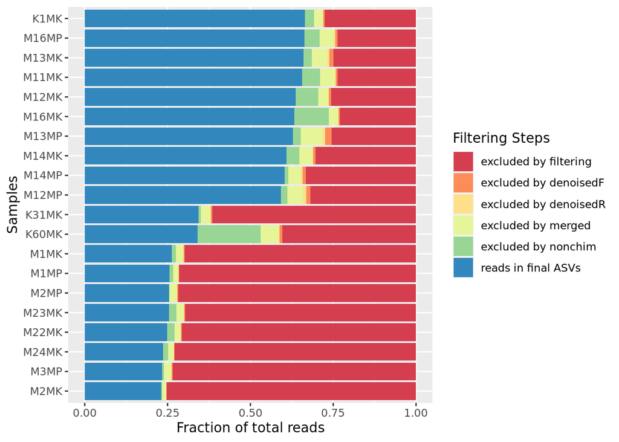

Between 23.11% and 66.41% reads per sample (average 45.4%) were retained for analysis within DADA2 steps.

The proportion of lost reads per processing stage and sample should not be too high, totalling typically <50%. Samples that are very different in lost reads (per stage) to the majority of samples must be compared with caution, because an unusual problem (e.g. during nucleotide extraction, library preparation, or sequencing) could have occurred that might add bias to the analysis.

## 4.3 Inferred ASVs

Finally, 33250 amplicon sequence variants (ASVs) were obtained across all samples. The ASVs can be found in `dada2/ASV_seqs.fasta`. And the corresponding quantification of the ASVs across samples is in `dada2/ASV_table.tsv`. An extensive table containing both was saved as `dada2/DADA2_table.tsv`. ASVs were inferred for each sample independently.

# 5 Post processing of ASVs

## 5.1 rRNA detection

[Barrnap](https://github.com/tseemann/barrnap) classifies the ASVs into the origin domain (including mitochondrial origin).

Barrnap classified 32200 ( 96.84 %) ASVs as most similar to Bacteria, 83 ( 0.25 %) ASVs to Archea, 28 ( 0.08 %) ASVs to Mitochondria, 13 ( 0.04 %) ASVs to Eukaryotes, and 926 ( 2.78 %) were below similarity threshold to any kingdom.

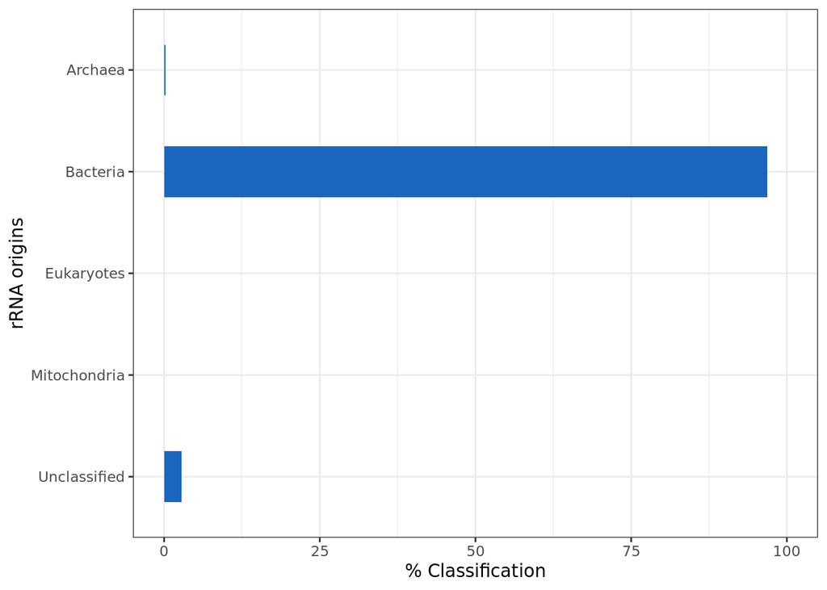

rRNA classification results can be found in folder barrnap.

## 5.2 Sequence length

A length filter was used to reduce potential contamination. Before filtering, ASVs had the following length profile (count of 1 was transformed to 1.5 to allow plotting on log10 scale):

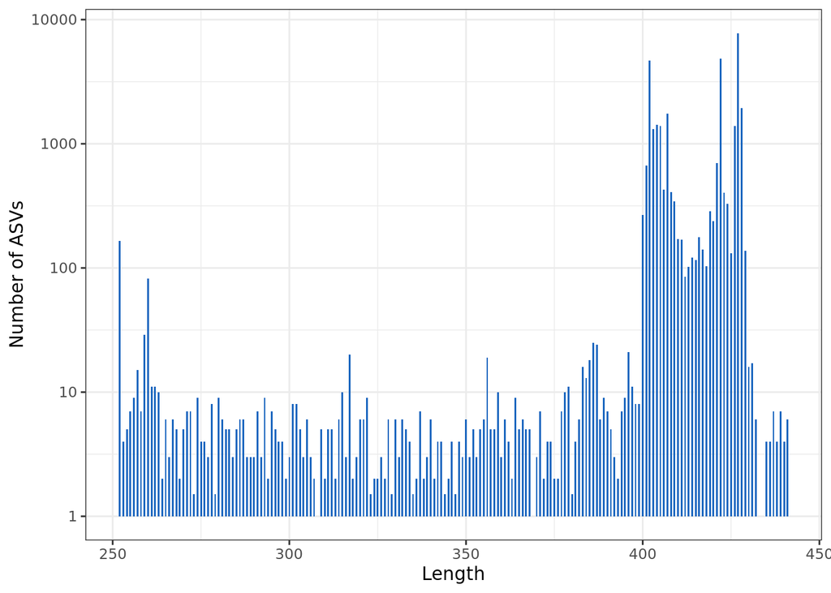

Filtering omitted all ASVs with length lower than 350 or above 700 bp.

The following table shows read counts for each sample before and after filtering:

|  | sample | input | output | retained% |
| --- | --- | --- | --- | --- |
| 1 | K10MK | 288147 | 287638 | 99.82 |
| 2 | K11MK | 275035 | 274908 | 99.95 |
| 3 | K12MK | 294938 | 294761 | 99.94 |
| 4 | K13MK | 279605 | 279325 | 99.9 |
| 5 | K14MK | 317554 | 317469 | 99.97 |
| 6 | K15MK | 187985 | 187740 | 99.87 |
| 7 | K16MK | 259287 | 259207 | 99.97 |
| 8 | K17MK | 227732 | 227344 | 99.83 |
| 9 | K18MK | 250354 | 250138 | 99.91 |
| 10 | K19MK | 240394 | 240124 | 99.89 |

[output cut: 136 more lines]

In average 2.625137 % reads were removed, but at most 37.21 % reads per sample.

The number of ASVs was reduced by 734 ( 2.21 %), from 33250 to 32516 ASVs.

Length filter results can be found in folder asv_length_filter.

# 6 Taxonomic Classification

## 6.1 DADA2

The taxonomic classification was performed by [DADA2](https://pubmed.ncbi.nlm.nih.gov/27214047/) using the database: `Silva 138.2 prokaryotic SSU`. More details about the reference taxonomy database can be found in the ‘Methods section’.

DADA2 classified 99.75 % ASVs at Kingdom level, 98.69 % ASVs at Phylum level, 98.23 % ASVs at Class level, 95.89 % ASVs at Order level, 86.81 % ASVs at Family level, 71.72 % ASVs at Genus level, 23.57 % ASVs at Species level, 5.83 % ASVs at Species_exact level.

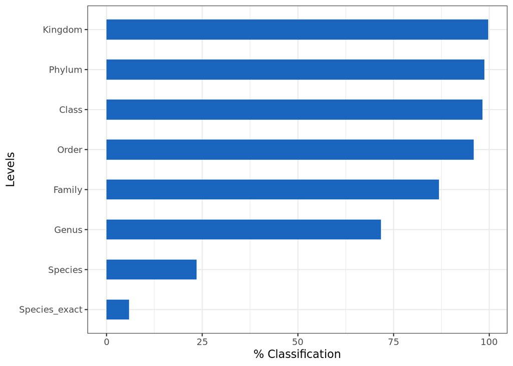

DADA2 taxonomy assignments can be found in folder dada2 in files `ASV_tax_*.tsv`.

# 7 Downstream analysis with QIIME2

Files that were input to [QIIME2](https://www.nature.com/articles/s41587-019-0209-9) can be found in folder qiime2/input/. Results of taxonomic classification of DADA2 was used in all following analysis, see in the above sections.

## 7.1 ASV filtering

Unwanted taxa are often off-targets generated in PCR with primers that are not perfectly specific for the target DNA. For 16S rRNA sequencing mitrochondria and chloroplast sequences are typically removed because these are frequent unwanted non-bacteria PCR products. ASVs were removed when the taxonomic string contained any of `mitochondria,chloroplast` (comma separated). Consequently, 32516 ASVs were reduced by 744 ( 2.29 %) to 31772 . The following table shows read counts for each sample before and after filtering:

|  | sample | input | filtered | lost | retained% | lost% |
| --- | --- | --- | --- | --- | --- | --- |
| 1 | K10MK | 287638 | 277500 | 10138 | 96.48 | 3.52 |
| 2 | K11MK | 274908 | 265264 | 9644 | 96.49 | 3.51 |
| 3 | K12MK | 294761 | 290993 | 3768 | 98.72 | 1.28 |
| 4 | K13MK | 279325 | 265354 | 13971 | 95 | 5 |
| 5 | K14MK | 317469 | 314090 | 3379 | 98.94 | 1.06 |
| 6 | K15MK | 187740 | 187740 | 0 | 100 | 0 |
| 7 | K16MK | 259207 | 238229 | 20978 | 91.91 | 8.09 |
| 8 | K17MK | 227344 | 223832 | 3512 | 98.46 | 1.54 |
| 9 | K18MK | 250138 | 249782 | 356 | 99.86 | 0.14 |
| 10 | K19MK | 240124 | 239023 | 1101 | 99.54 | 0.46 |

[output cut: 136 more lines]

Tables with read count numbers and filtered abundance tables are in folder qiime2/abundance_tables.

## 7.2 Abundance tables

The abundance tables are the final data for further downstream analysis and visualisations. The tables are based on the computed ASVs and taxonomic classification, but after removal of unwanted taxa. Folder qiime2/abundance_tables contains tap-separated files (.tsv) that can be opened by any spreadsheet software.

## 7.3 Relative abundance tables

Absolute abundance tables produced by the previous steps contain count data, but the compositional nature of 16S rRNA amplicon sequencing requires sequencing depth normalisation. This step computes relative abundance tables using TSS (Total Sum Scaling normalisation) for various taxonomic levels and detailed tables for all ASVs with taxonomic classification, sequence and relative abundance for each sample. Typically used for in depth investigation of taxa abundances. Folder qiime2/rel_abundance_tables contains tap-separated files (.tsv) that can be opened by any spreadsheet software.

## 7.4 Barplot

Interactive abundance plot that aids exploratory browsing the discovered taxa and their abundance in samples and allows sorting for associated meta data. Folder qiime2/barplot contains barplots, click qiime2/barplot/index.html to open it in your web browser.

# 8 R objects

Microbiome data can be analysed and visualized with certain R packages. For convenience, R objects in RDS format are provided.

[Phyloseq](https://doi.org/10.1371/journal.pone.0061217) objects and can be loaded directely into R with package ‘phyloseq’. The objects contain an ASV abundance table and a taxonomy table. If available, metadata and phylogenetic tree will also be included in the phyloseq object. The files can be found in folder phyloseq.

[TreeSummarizedExperiment](https://doi.org/10.12688/f1000research.26669.2) (TreeSE, TSE) objects can be loaded into R with package ‘TreeSummarizedExperiment’. and contain an ASV abundance table, a taxonomy table, and sequences. If available, metadata and phylogenetic tree will also be included in the object. The files can be found in folder treesummarizedexperiment.

# 9 Methods

## 9.1 Proposed methods section

Data was processed using nf-core/ampliseq version 2.14.0 (doi: [10.5281/zenodo.1493841](https://zenodo.org/badge/latestdoi/150448201)) ([Straub et al., 2020](https://doi.org/10.3389/fmicb.2020.550420)) of the nf-core collection of workflows ([Ewels et al., 2020](https://dx.doi.org/10.1038/s41587-020-0439-x)), utilising reproducible software environments from the Bioconda ([Grüning et al., 2018](https://pubmed.ncbi.nlm.nih.gov/29967506/)) and Biocontainers ([da Veiga Leprevost et al., 2017](https://pubmed.ncbi.nlm.nih.gov/28379341/)) projects.

Data quality was evaluated with FastQC ([Andrews, 2010](https://www.bioinformatics.babraham.ac.uk/projects/fastqc/)) and summarized with MultiQC ([Ewels et al., 2016](https://pubmed.ncbi.nlm.nih.gov/27312411/)). Cutadapt ([Marcel et al., 2011](https://doi.org/10.14806/ej.17.1.200)) trimmed primers and all untrimmed sequences were discarded. Sequences that did not contain primer sequences were considered artifacts. Less than 31.5% of the sequences were discarded per sample and a mean of 94.8% of the sequences per sample passed the filtering. Adapter and primer-free sequences were processed sample-wise (independent) with DADA2 ([Callahan et al., 2016](https://pubmed.ncbi.nlm.nih.gov/27214047/)) to eliminate PhiX contamination, trim reads (before median quality drops below 25 and at least 75% of reads are retained; forward reads at 252 bp and reverse reads at 201 bp, reads shorter than this were discarded), discard reads with > 2 expected errors, correct errors, merge read pairs, and remove polymerase chain reaction (PCR) chimeras; ultimately, 33250 amplicon sequencing variants (ASVs) were obtained across all samples. Between 23.11% and 66.41% reads per sample (average 45.4%) were retained. The ASV count table contained in total 24682324 counts, at least 20102 and at most 393119 per sample (average 169057).

734 ASVs with length lower than 350 or above 700 bp were removed with less than 37.21% counts per sample (32516 ASVs passed).

Taxonomic classification was performed by DADA2 and the database ‘Silva 138.2 prokaryotic SSU’ (`Quast C, Pruesse E, Yilmaz P, Gerken J, Schweer T, Yarza P, Peplies J, Glöckner FO. The SILVA ribosomal RNA gene database project: improved data processing and web-based tools. Nucleic Acids Res. 2013 Jan;41(Database issue):D590-6. doi: 10.1093/nar/gks1219. Epub 2012 Nov 28. PMID: 23193283; PMCID: PMC3531112.`).

ASV sequences, abundance and DADA2 taxonomic assignments were loaded into QIIME2 ([Bolyen et al., 2019](https://www.nature.com/articles/s41587-019-0209-9)). Of 32516 ASVs, 744 were removed because the taxonomic string contained any of (mitochondria,chloroplast) (31772 ASVs passed). Within QIIME2, the final microbial community data was visualized in a barplot.

> **WARNING** This methods section is lacking software versions, these can be found in MultiQC’s report section Software Versions or in folder pipeline_info file `software_versions.yml`.

## 9.2 Reference databases

Taxonomic classification by DADA2:

- database: `Silva 138.2 prokaryotic SSU`
- files: `[https://zenodo.org/records/14169026/files/silva_nr99_v138.2_toSpecies_trainset.fa.gz, https://zenodo.org/records/14169026/files/silva_v138.2_assignSpecies.fa.gz]`
- citation: `Quast C, Pruesse E, Yilmaz P, Gerken J, Schweer T, Yarza P, Peplies J, Glöckner FO. The SILVA ribosomal RNA gene database project: improved data processing and web-based tools. Nucleic Acids Res. 2013 Jan;41(Database issue):D590-6. doi: 10.1093/nar/gks1219. Epub 2012 Nov 28. PMID: 23193283; PMCID: PMC3531112.`

## 9.3 MultiQC methods summary

[MultiQC](https://multiqc.info/) summarized computational methods in multiqc/multiqc_report.html. The proposed short methods description can be found in MultiQC’s Methods Description, versions of software collected at runtime in MultiQC’s Software Versions, and a summary of non-default parameter in MultiQC’s Workflow Summary.

## 9.4 Nextflow and pipeline information

Technical information to the pipeline run are collected in folder pipeline_info, including software versions collected at runtime in file `software_versions.yml` (can be viewed with a text editor), all parameter settings in file `params_{date}_{time}.json` (can be viewed with a text editor), execution report in file `execution_report_{date}_{time}.html`, execution trace in file `execution_trace_{date}_{time}.txt`, execution timeline in file `execution_timelime_{date}_{time}.html`, and pipeline direct acyclic graph (DAG) in file `pipeline_dag_{date}_{time}.html`.

# 10 Final notes

This report (file `summary_report.html`) is located in folder summary_report of the original pipeline results folder. In this file, all links to files and folders are relative, therefore hyperlinks will only work when the report is at its original place in the pipeline results folder. Plots specifically produced for this report (if any) can be also found in folder summary_report.

A comprehensive read count report throughout the pipeline can be found in the base results folder in file `overall_summary.tsv`.

Please cite the [pipeline publication](https://doi.org/10.3389/fmicb.2020.550420) and any software tools used by the pipeline (see citations) when you use any of the pipeline results in your study.